# ggrob_OriginalHomeworkCode_03

Gianna Grob

10/2/2019

Nicola Kriefall comments:

line 37: there was an extra ‘f <-’ here so I deleted that

Question 1: I got the same answers for means but a different answer for the population standard deviations, but I don’t know who’s correct, so maybe we should check with our third group member?

Question 4: Nice job plotting the non-normal ones

Question 6: We got very different answers for standard deviations. Here I think it’s because I constructed a list of 100 means first, then took the mean & standard deviation of the list of 100 means, whereas you calculated the mean & standard deviations of your entire sample data list (a list of thousands of values). I think if you had done it my way all of your plots in the end would have been normally distributed (even the ones that were non-normal originally), that’s how mine ended up.

Overall awesome job! Very well annotated

# Introduction

This is the code for the third homework assignment for AN597. It utilizes code from Modules 3-8. The data included in this homework includes the first and last name and gender of the entire population of 1000 people who have survived the zombie apocalypse and are now ekeing out an existence somewhere on the East Coast, along with several other variables (height, weight, age, number of years of education, number of zombies they have killed, and college major).

## Loading in the data and packages needed

First, I have to load in the data set provided by Professor Schmiit from his [GitHub repo](https://github.com/fuzzyatelin/fuzzyatelin.github.io/tree/master/AN597_Fall19/).

```r
library(curl)
f <- curl("https://raw.githubusercontent.com/fuzzyatelin/fuzzyatelin.github.io/master/AN597_Fall19/zombies.csv")
d <- read.csv(f, header = TRUE, sep = ",", stringsAsFactors = FALSE) #Our vector for all of the zombie data is "d". This will be the vector we use for the homework when the whole data set is needed.
head(d) #See a summary of the data.
```

```
##   id first_name last_name gender   height   weight zombies_killed
## 1  1      Sarah    Little Female 62.88951 132.0872              2
## 2  2       Mark    Duncan   Male 67.80277 146.3753              5
## 3  3    Brandon     Perez   Male 72.12908 152.9370              1
## 4  4      Roger   Coleman   Male 66.78484 129.7418              5
## 5  5      Tammy    Powell Female 64.71832 132.4265              4
## 6  6    Anthony     Green   Male 71.24326 152.5246              1
##   years_of_education                           major      age
## 1                  1                medicine/nursing 17.64275
## 2                  3 criminal justice administration 22.58951
## 3                  1                       education 21.91276
## 4                  6                  energy studies 18.19058
## 5                  3                       logistics 21.10399
## 6                  4                  energy studies 21.48355
```

```r
library(ggplot2) #Load ggplot2 package.
```

## Question 1

Calculate the population mean and standard deviation for each quantitative random variable (height, weight, age, number of zombies killed, and years of education). NOTE: You will not want to use the built in var() and sd() commands as these are for samples.

### Height:

```r
h <- d$height #Create vector that has all of the heights of the people in the data set.

#Finding the mean:

pm1 <- function(h){sum(h)/length(h)}
pm1(h)
```

```
## [1] 67.6301
```

```r
#Finding the standard deviation:

var(h) * ((length(h)-1)/length(h)) #The difference from sample variance is by a factor of ((N-1)/N), so I do that here.
```

```
## [1] 18.55861
```

### Weight:

```r
w <- d$weight #Create vector that has all of the weights of the people in the data set.

#Finding the mean:

pm2 <- function(h){sum(w)/length(w)}
pm2(w)
```

```
## [1] 143.9075
```

```r
#Finding the standard deviation:

var(w) * ((length(w)-1)/length(w))
```

```
## [1] 338.2604
```

### Age:

```r
a <- d$age #Create vector that has all of the ages of the people in the data set.

#Finding the mean:

pm3 <- function(a){sum(a)/length(a)}
pm3(a)
```

```
## [1] 20.04696
```

```r
#Finding the standard deviation:

var(a) * ((length(a)-1)/length(a))
```

```
## [1] 8.782822
```

### Number of Zombies Killed:

```r
z <- d$zombies_killed #Create vector that has all of the numbers of zombies killed by the people in the data set.

#Finding the mean:

pm4 <- function(z){sum(z)/length(z)}
pm4(z)
```

```
## [1] 2.992
```

```r
#Finding the standard deviation:

var(z) * ((length(z)-1)/length(z))
```

```
## [1] 3.053936
```

### Years of Education:

```r
y <- d$years_of_education #Create vector that has all of the years of education of the people in the data set.

#Finding the mean:

pm5 <- function(y){sum(y)/length(y)}
pm5(y)
```

```
## [1] 2.996
```

```r
#Finding the standard deviation:

var(y) * ((length(y)-1)/length(y))
```

```
## [1] 2.807984
```

## Question 2

Use {ggplot} to make boxplots of each of these variables by gender.

```r
g <- d$gender #Create vector for gender for the boxplots.
```

I will be using the vectors that I created in the last question, as well as the “g” vector I just created in the boxplots. The “g” vector will always take the “x” value, while the other vectors will take the place of the “y” value in the scatterplots.

### Height

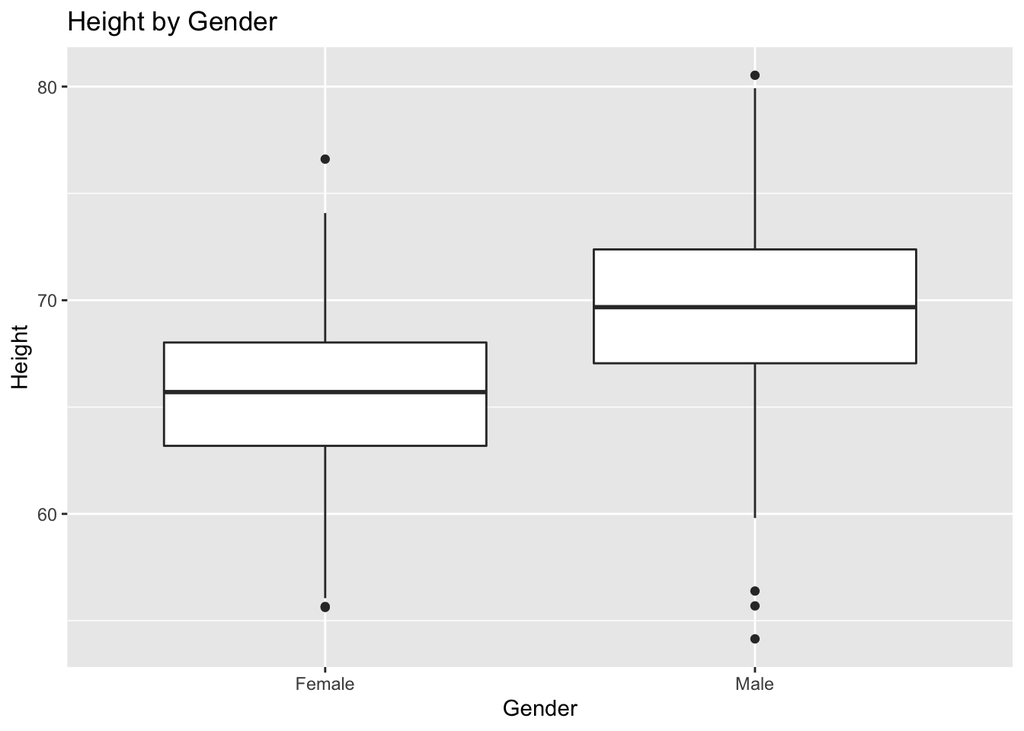

```r
ggplot(d, aes(x = g, y = h)) + labs(title="Height by Gender", x="Gender", y="Height") + geom_boxplot() #Create boxplot for height with gender.
```

### Weight

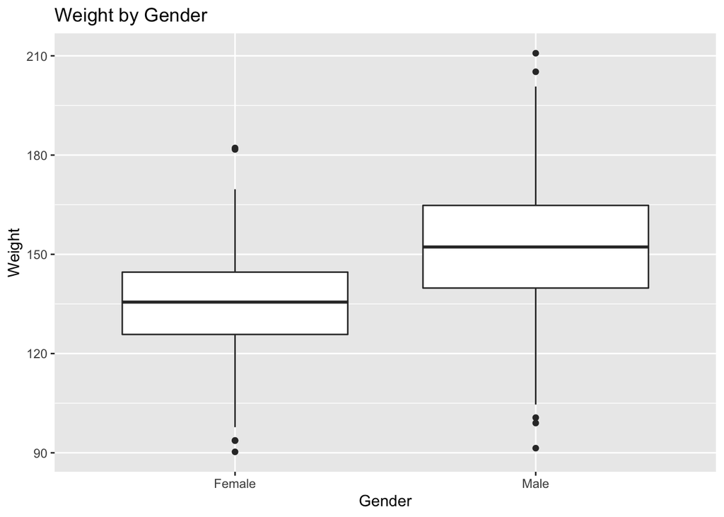

```r
ggplot(d, aes(x = g, y = w)) + labs(title="Weight by Gender", x="Gender", y="Weight") + geom_boxplot() #Create boxplot for weight with gender.
```

### Age

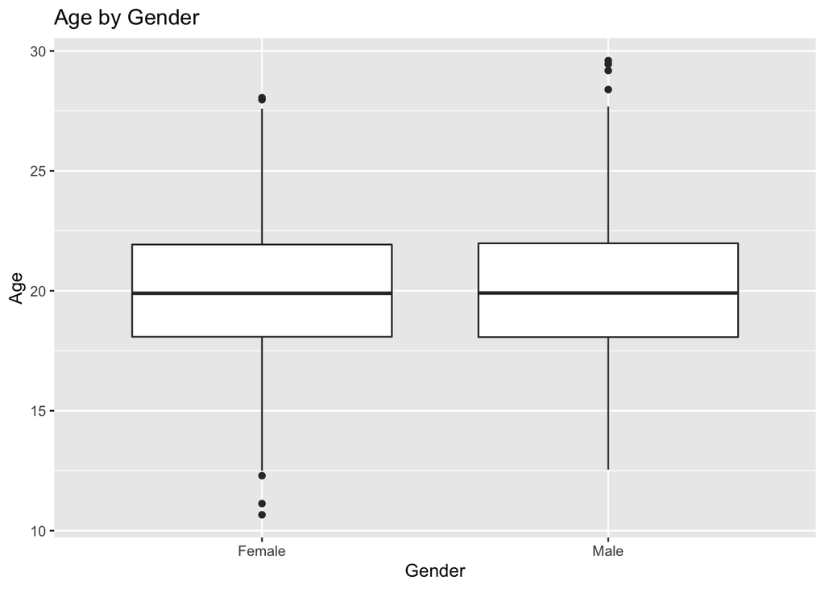

```r
ggplot(d, aes(x = g, y = a)) + labs(title="Age by Gender", x="Gender", y="Age") + geom_boxplot() #Create boxplot for age with gender.
```

### Number of Zombies Killed

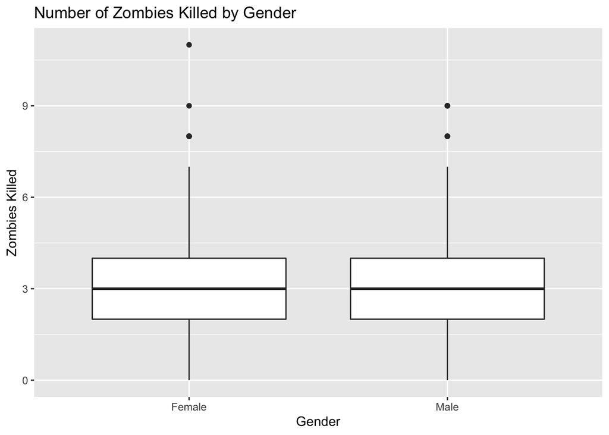

```r
ggplot(d, aes(x = g, y = z)) + labs(title="Number of Zombies Killed by Gender", x="Gender", y="Zombies Killed") + geom_boxplot() #Create boxplot for number of zombies killed with gender.
```

### Years of Education

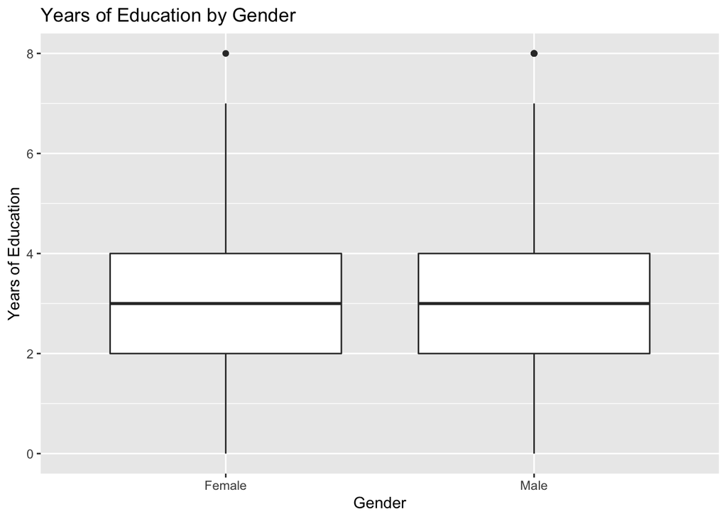

```r
ggplot(d, aes(x = g, y = y)) + labs(title="Years of Education by Gender", x="Gender", y="Years of Education") + geom_boxplot() #Create boxplot for years of education with gender.
```

## Question 3

Use {ggplot} to make scatterplots of height and weight in relation to age. Do these variables seem to be related? In what way?

I will continue to use the vectors I created in the above questions. These will take the place of the “x” and “y” values in the scatterplots.

### Height Scatterplot

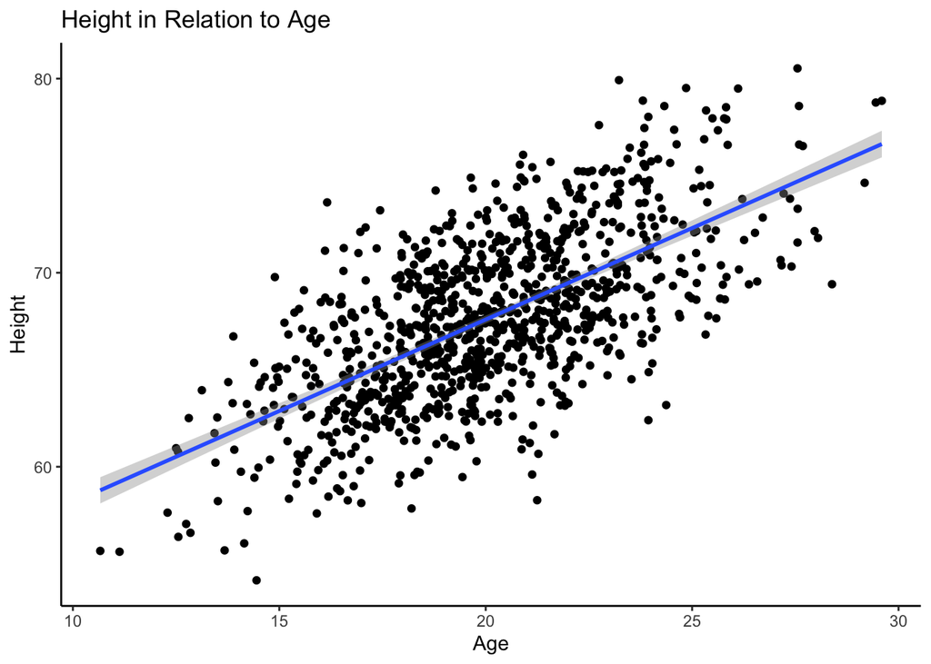

```r
ggplot(d, aes(x=a, y=h)) + geom_point() + geom_smooth(method=lm) + labs(title="Height in Relation to Age", x="Age", y="Height") + theme_classic() #Create scatterplot with height in relationship to age.
```

### Weight Scatterplot

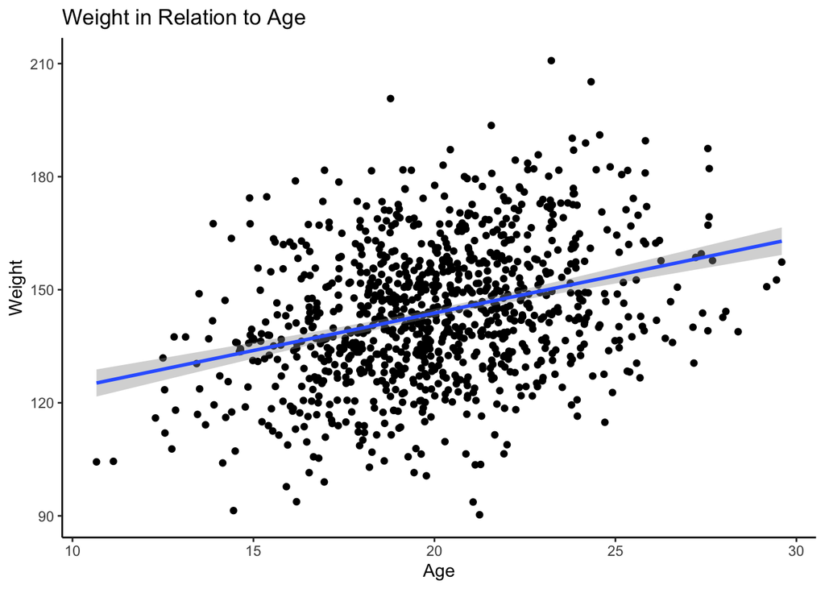

```r
ggplot(d, aes(x=a, y=w)) + geom_point() + geom_smooth(method=lm) + labs(title="Weight in Relation to Age", x="Age", y="Weight") + theme_classic() #Create scatterplot with weight in relationship to age.
```

According to the scatterplots, height is more related to age than weight is related to age. They both appear to be slightly related, as the regression lines follow a positive linear pattern for both, but the line is more steep for the height scatterplot. Therefore, I would say height is more related to age than weight.

## Question 4

Using histograms and Q-Q plots, check whether the quantitative variables seem to be drawn from a normal distribution. Which seem to be and which do not (hint: not all are drawn from the normal distribution)? For those that are not normal, can you determine from which common distribution they are drawn?

In this question I will continue to use the vectors created earlier.

### Height

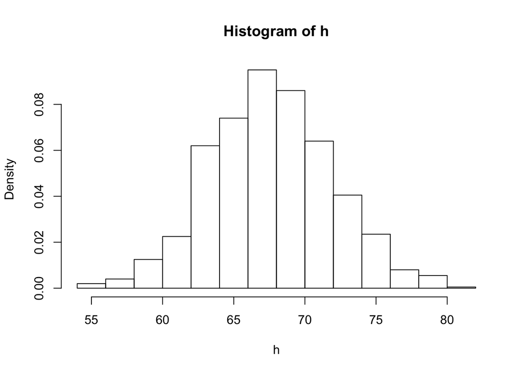

```r
hist(h, probability = TRUE) #Create histogram for height values
```

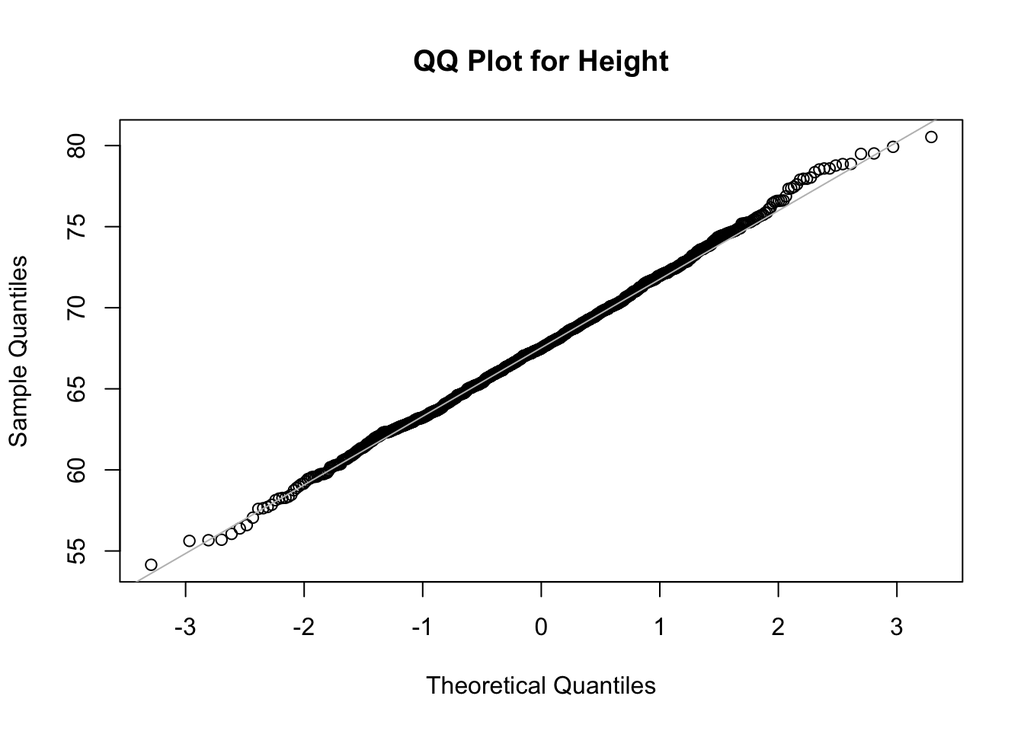

```r
qqnorm(h,main="QQ Plot for Height")
qqline(h,col="gray") #Create Q-Q plot for height values.
```

According to the two plots, height has a normal distribution.

### Weight

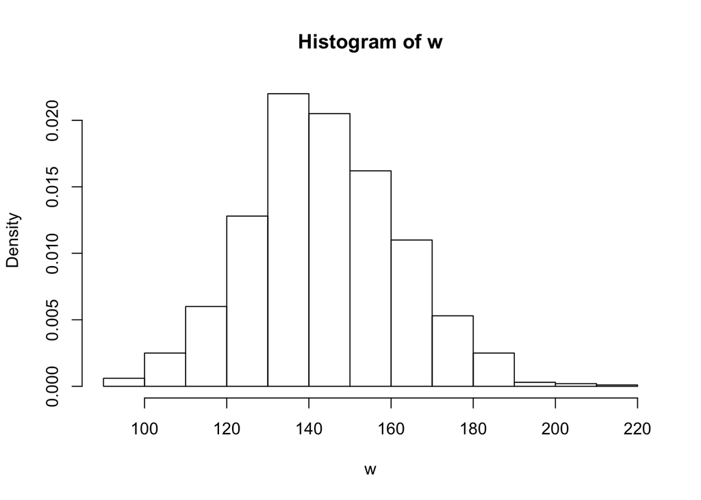

```r
hist(w, probability = TRUE) #Create histogram for weight values
```

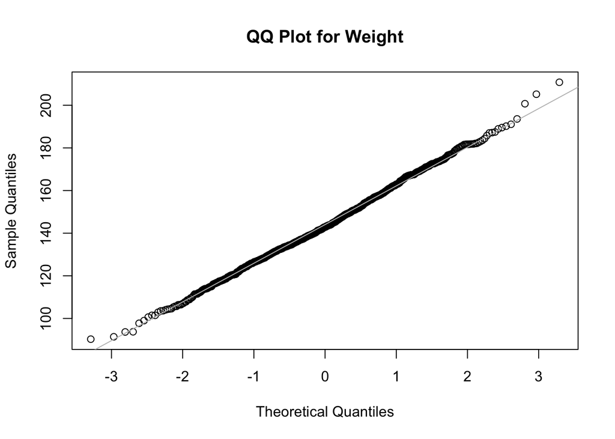

```r
qqnorm(w,main="QQ Plot for Weight")
qqline(w,col="gray") #Create Q-Q plot for weight values.
```

According to the two plots, weight has a normal distribution.

### Age

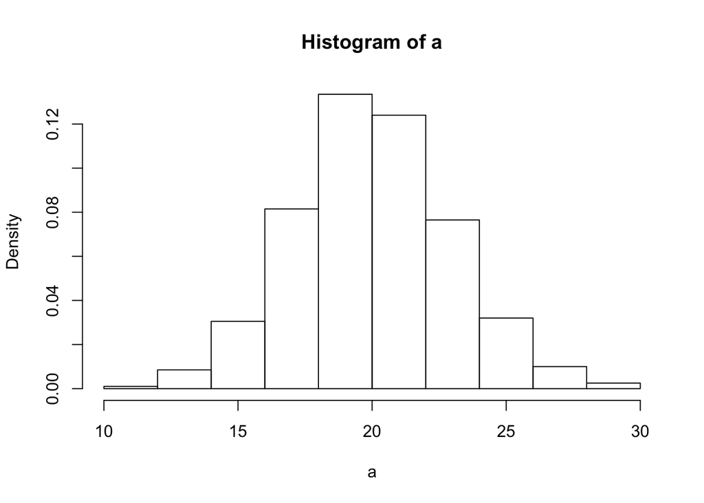

```r
hist(a, probability = TRUE) #Create histogram for age values
```

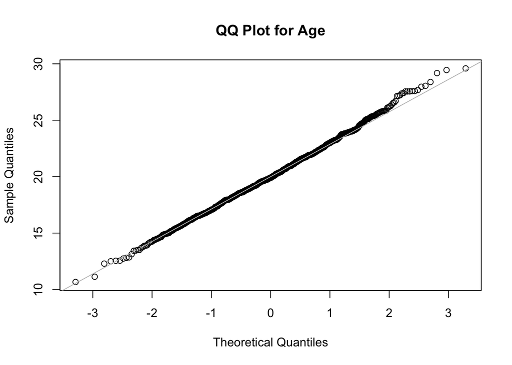

```r
qqnorm(a,main="QQ Plot for Age")
qqline(a,col="gray") #Create Q-Q plot for age values.
```

According to the two plots, age has a normal distrbution.

### Number of Zombies Killed

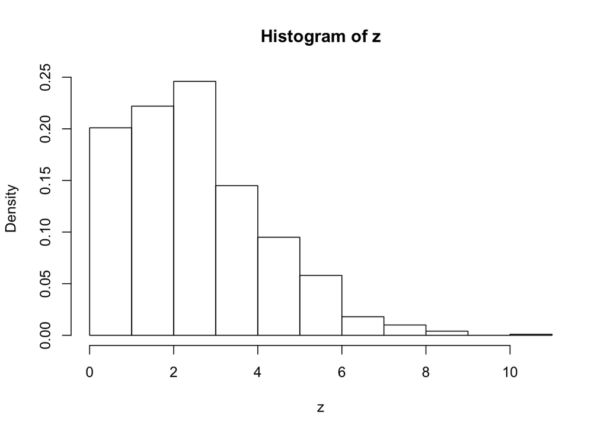

```r
hist(z, probability = TRUE) #Create histogram for number of zombies killed values
```

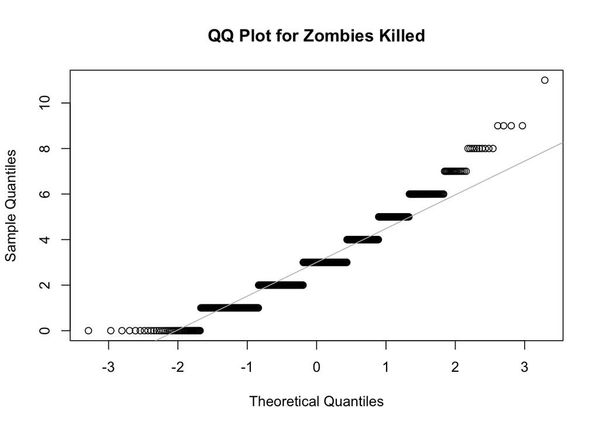

```r
qqnorm(z,main="QQ Plot for Zombies Killed")
qqline(z,col="gray") #Create Q-Q plot for number of zombies killed values.
```

According to the two plots, the number of zombies killed does not have a normal distribution. It appears to have a Poisson distribution, which I can test for below.

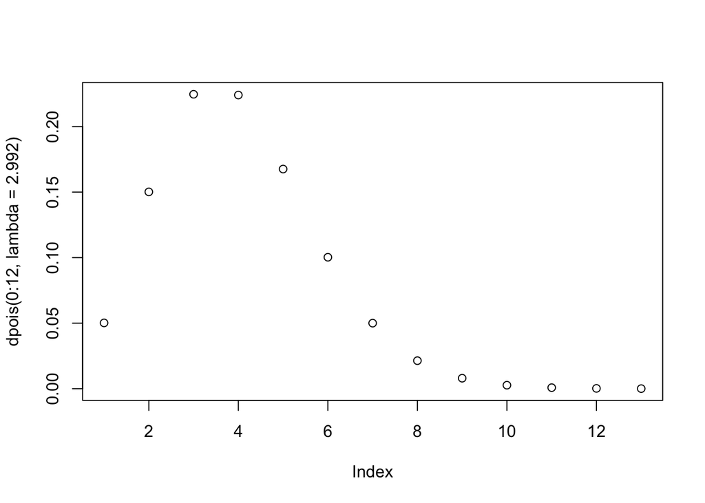

```r
plot(dpois(0:12, lambda = 2.992)) #Create plot showing Poisson distribution with range being 0 to 12, the max amount of zombies killed, and lambda being the mean.
```

This looks more normally distributed than before.

### Years of Education

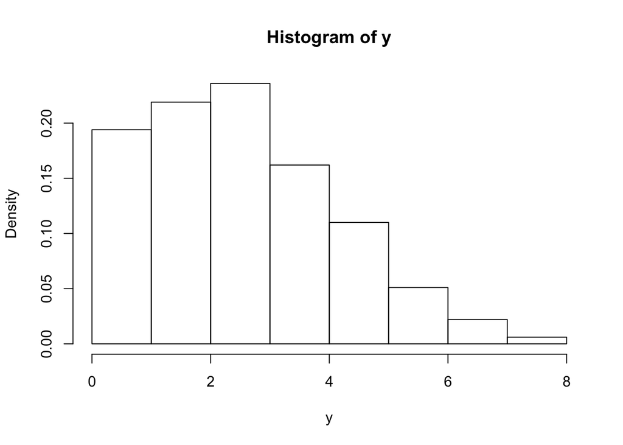

```r
hist(y, probability = TRUE) #Create histogram for years of education values
```

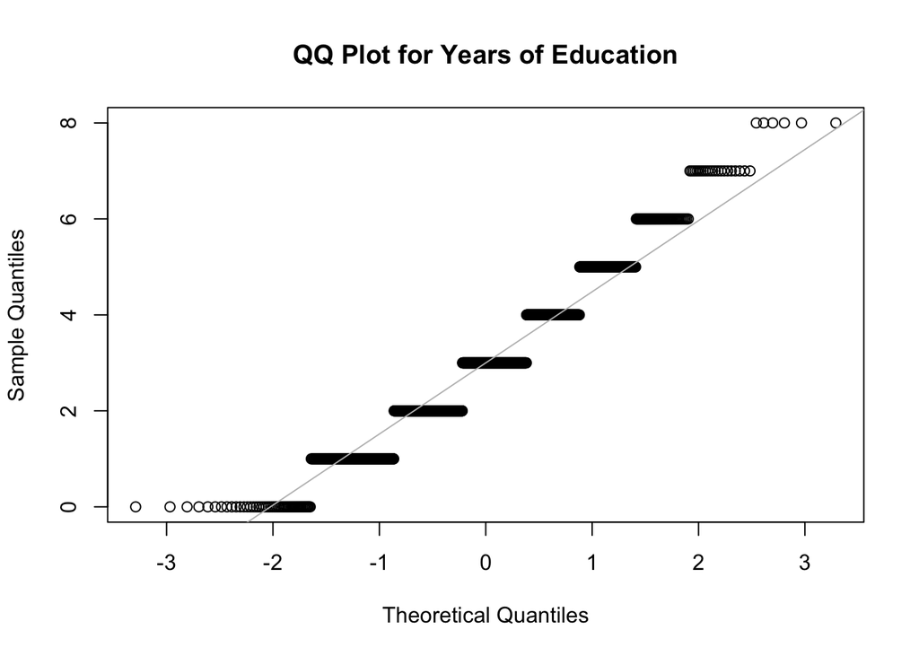

```r
qqnorm(y,main="QQ Plot for Years of Education")
qqline(y,col="gray") #Create Q-Q plot for years of education values.
```

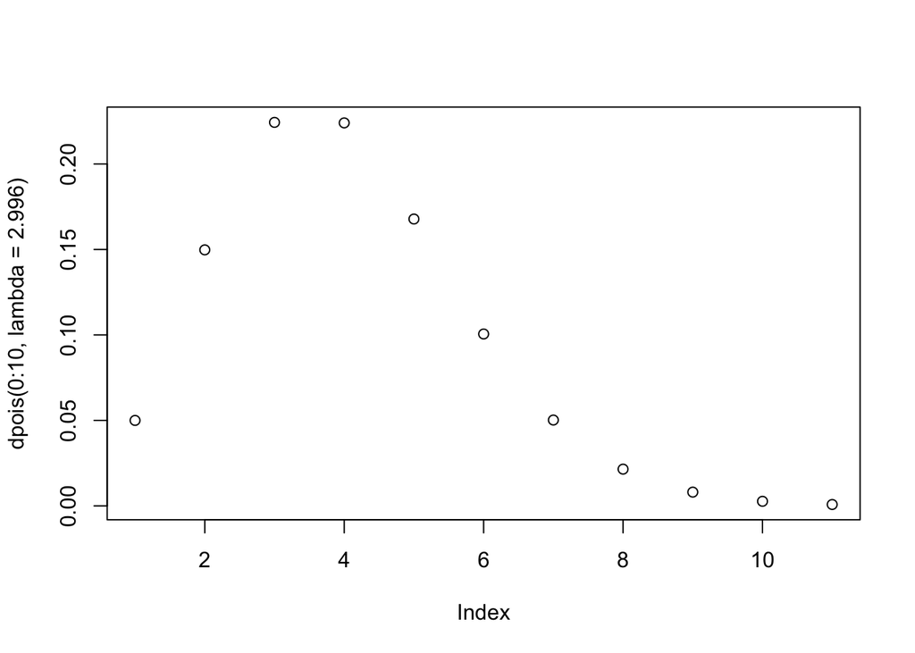

```r
plot(dpois(0:10, lambda = 2.996)) #Create plot for Poisson distribution with range being 0 to 10, 8 is the max, but I think 9 is a weird place to cut it off, as well as with lambda being the mean.
```

This also looks more normally distributed than before.

## Question 5

Now use the sample() function to sample ONE subset of 30 zombie survivors (without replacement) from this population and calculate the mean and sample standard deviation for each variable. Also estimate the standard error for each variable, and construct the 95% confidence interval for each mean. Note that for the variables that are not drawn from the normal distribution, you may need to base your estimate of the CIs on slightly different code than for the normal…

```r
s <- d[sample(nrow(d), 30), ] #Use vector with our dataset to create one sample of 30 people by picking whole rows instead of individual values.
s #Check our random sample
```

```
##      id first_name last_name gender   height   weight zombies_killed
## 921 921       Jose    Turner   Male 69.45476 143.5376              3
## 141 141        Ann      Dunn Female 65.36311 143.3415              3
## 854 854      Irene   Mendoza Female 65.03123 155.7343              2
## 451 451    Shirley   Stevens Female 66.58934 126.2100              2
## 171 171     Evelyn Gutierrez Female 66.40247 121.8163              2
## 457 457      Annie  Martinez Female 66.48461 125.2267              3
## 289 289      Bruce    Miller   Male 68.00579 133.0025              4
## 356 356      Larry   Simpson   Male 70.42895 134.4735              2
## 472 472      Annie  Thompson Female 66.12076 134.5862              0
## 331 331     Gerald     Myers   Male 72.06090 153.2824              4
## 127 127       Judy    Fields Female 62.82903 127.7302              5
## 312 312      Paula      Hall Female 60.34227 114.5168              2
## 822 822        Amy      Rice Female 66.78995 146.1663              1
## 830 830  Katherine    Bailey Female 62.95986 139.1263              1
```

[output cut: 47 more lines]

### Height

```r
#Create vector for height with small sample:
sh <- s$height
sh
```

```
##  [1] 69.45476 65.36311 65.03123 66.58934 66.40247 66.48461 68.00579
##  [8] 70.42895 66.12076 72.06090 62.82903 60.34227 66.78995 62.95986
## [15] 74.75869 74.89581 75.23595 67.70104 66.55435 71.95173 67.89409
## [22] 63.06785 72.59502 66.88320 71.49300 68.78755 65.37115 60.95832
## [29] 63.99734 64.40630
```

```r
#Finding sample mean:
shm <- mean(sh) #Use mean function to find the sample mean
shm
```

```
## [1] 67.51381
```

```r
#Finding sample standard deviation:
shsd <- sd(sh) #Use the standard deviation function to find the sample standard deviation.
shsd
```

```
## [1] 4.000596
```

```r
#Finding standard error:
hse <- shsd/sqrt(30) #Use standard deviation and devide by sample size to find the standard error
hse
```

```
## [1] 0.7304056
```

```r
#Finding CI:
lowerh <- shm - qnorm(1 - 0.05/shsd) * hse #Find the lower confidence interval for 95% with mean, standard deviation, and standard error
upperh <- shm + qnorm(1 - 0.05/shsd) * hse #Find the upper confidence interval for 95% with mean, standard deviation, and standard error
cih <- c(lowerh, upperh) #Put two values into confidence interval function
cih
```

```
## [1] 65.87664 69.15099
```

### Weight

```r
#Create vector for weight with small sample:
sw <- s$weight
sw
```

```
##  [1] 143.5376 143.3415 155.7343 126.2100 121.8163 125.2267 133.0025
##  [8] 134.4735 134.5862 153.2824 127.7302 114.5168 146.1663 139.1263
## [15] 145.5468 162.1975 184.3939 143.1754 129.9026 177.4089 159.2552
## [22] 114.5466 155.7041 124.5944 162.2126 173.4652 147.0078 131.8955
## [29] 120.4763 113.9125
```

```r
#Finding sample mean:
swm <- mean(sw) #Use mean function to find the sample mean
swm
```

```
## [1] 141.4815
```

```r
#Finding sample standard deviation:
swsd <- sd(sw) #Use the standard deviation function to find the sample standard deviation.
swsd
```

```
## [1] 18.90688
```

```r
#Finding standard error:
wse <- swsd/sqrt(30) #Use standard deviation and devide by sample size to find the standard error
wse
```

```
## [1] 3.451908
```

```r
#Finding CI:
lowerw <- swm - qnorm(1 - 0.05/swsd) * wse #Find the lower confidence interval for 95% with mean, standard deviation, and standard error
upperw <- swm + qnorm(1 - 0.05/swsd) * wse #Find the upper confidence interval for 95% with mean, standard deviation, and standard error
ciw <- c(lowerw, upperw) #Put two values into confidence interval function
ciw
```

```
## [1] 131.8546 151.1085
```

### Age

```r
#Create vector for age with small sample:
sa <- s$age
sa
```

```
##  [1] 20.94367 15.65899 16.70843 21.59101 22.70490 22.82317 21.71987
##  [8] 23.05967 20.51588 23.51740 19.73793 17.17613 18.92234 18.73167
## [15] 23.96539 19.63954 22.23308 22.76151 20.11425 21.32535 18.51140
## [22] 18.62427 20.81649 20.91053 19.91412 17.86783 18.55335 12.50085
## [29] 17.79963 18.06166
```

```r
#Finding sample mean:
sam <- mean(sa) #Use mean function to find the sample mean
sam
```

```
## [1] 19.91368
```

```r
#Finding sample standard deviation:
sasd <- sd(sa) #Use the standard deviation function to find the sample standard deviation.
sasd
```

```
## [1] 2.568091
```

```r
#Finding standard error:
ase <- sasd/sqrt(30) #Use standard deviation and devide by sample size to find the standard error
ase
```

```
## [1] 0.4688672
```

```r
#Finding CI:
lowera <- sam - qnorm(1 - 0.05/sasd) * ase #Find the lower confidence interval for 95% with mean, standard deviation, and standard error
uppera <- sam + qnorm(1 - 0.05/sasd) * ase #Find the upper confidence interval for 95% with mean, standard deviation, and standard error
cia <- c(lowera, uppera) #Put two values into confidence interval function
cia
```

```
## [1] 18.94555 20.88181
```

### Number of Zombies Killed

Note: The confidence interval code will have to be different due to a Poisson distribution!

```r
#Create vector for number of zombies killed with small sample:
sz <- s$zombies_killed
sz
```

```
##  [1] 3 3 2 2 2 3 4 2 0 4 5 2 1 1 2 5 5 5 4 7 4 3 6 3 5 1 2 4 2 3
```

```r
#Finding sample mean:
szm <- mean(sz) #Use mean function to find the sample mean
szm
```

```
## [1] 3.166667
```

```r
#Finding sample standard deviation:
szsd <- sd(sz) #Use the standard deviation function to find the sample standard deviation.
szsd
```

```
## [1] 1.641768
```

```r
#Finding standard error:
zse <- szsd/sqrt(30) #Use standard deviation and devide by sample size to find the standard error
zse
```

```
## [1] 0.2997445
```

```r
#Finding CI for Poisson distribution:
lowerz <- szm - qpois(0.05, szm) * zse #Find the lower confidence interval for 95% with mean, standard deviation, and standard error
upperz <- szm + qpois(0.95, szm) * zse #Find the upper confidence interval for 95% with mean, standard deviation, and standard error
ciz <- c(lowerz, upperz) #Put two values into confidence interval function
ciz
```

```
## [1] 2.866922 4.965133
```

### Years of Education

Note: The confidence interval code will have to be different due to a Poisson distribution!

```r
#Create vector for years of education with small sample:
sy <- s$years_of_education
sy
```

```
##  [1] 6 2 3 1 5 1 3 4 2 1 3 3 2 2 1 4 2 1 2 4 2 4 4 1 3 3 5 2 8 6
```

```r
#Finding sample mean:
sym <- mean(sy) #Use mean function to find the sample mean
sym
```

```
## [1] 3
```

```r
#Finding sample standard deviation:
sysd <- sd(sy) #Use the standard deviation function to find the sample standard deviation.
sysd
```

```
## [1] 1.741977
```

```r
#Finding standard error:
yse <- sysd/sqrt(30) #Use standard deviation and devide by sample size to find the standard error
yse
```

```
## [1] 0.31804
```

```r
#Finding CI for Poisson distribution:
lowery <- sym - qpois(0.05, sym) * yse #Find the lower confidence interval for 95% with mean, standard deviation, and standard error
uppery <- sym + qpois(0.95, sym) * yse #Find the upper confidence interval for 95% with mean, standard deviation, and standard error
ciy <- c(lowery, uppery) #Put two values into confidence interval function
ciy
```

```
## [1] 2.68196 4.90824
```

## Question 6

Now draw 99 more random samples of 30 zombie apocalypse survivors, and calculate the mean for each variable for each of these samples. Together with the first sample you drew, you now have a set of 100 means for each variable (each based on 30 observations), which constitutes a sampling distribution for each variable. What are the means and standard deviations of this distribution of means for each variable? How do the standard deviations of means compare to the standard errors estimated in [5]? What do these sampling distributions look like (a graph might help here)? Are they normally distributed? What about for those variables that you concluded were not originally drawn from a normal distribution?

### Height

```r
# Create a vector for the variable with 99 simulations:
nsh <- replicate(99,sample(d$height, 30, replace = FALSE))
nsh
```

[output not shown]

[output cut: 450 more lines]

```r
#Find mean:
nshm <- mean(nsh)
nshm
```

```
## [1] 67.55663
```

```r
#Find standard deviation:
nshsd <- sd(nsh)
nshsd
```

```
## [1] 4.223581
```

The means are very close for both the one sample and the 99 samples, but the standard deviations are not as close.

### Weight

```r
# Create a vector for the variable with 99 simulations:
nsw <- replicate(99,sample(d$weight, 30, replace = FALSE))
nsw
```

[output not shown]

[output cut: 450 more lines]

```r
#Find mean:
nswm <- mean(nsw)
nswm
```

```
## [1] 143.7724
```

```r
#Find standard deviation:
nswsd <- sd(nsw)
nswsd
```

```
## [1] 18.37693
```

The means for the one sample and the 99 samples are very close while the standard deviations are not as close.

### Age

```r
# Create a vector for the variable with 99 simulations:
nsa <- replicate(99,sample(d$age, 30, replace = FALSE))
nsa
```

[output not shown]

[output cut: 450 more lines]

```r
#Find mean:
nsam <- mean(nsa)
nsam
```

```
## [1] 19.9797
```

```r
#Find standard deviation:
nsasd <- sd(nsa)
nsasd
```

```
## [1] 2.98562
```

The means for the one sample and the 99 samples are very close while the standard deviations are not as close.

### Number of Zombies Killed

```r
# Create a vector for the variable with 99 simulations:
nsz <- replicate(99,sample(d$zombies_killed, 30, replace = FALSE))
nsz
```

[output not shown]

[output cut: 264 more lines]

```r
#Find mean:
nszm <- mean(nsz)
nszm
```

```
## [1] 2.993603
```

```r
#Find standard deviation:
nszsd <- sd(nsz)
nszsd
```

```
## [1] 1.752146
```

The means for the one sample and the 99 samples are very close and so are the standard deviation values.

### Years of Education

```r
# Create a vector for the variable with 99 simulations:
nsy <- replicate(99,sample(d$years_of_education, 30, replace = FALSE))
nsy
```

[output not shown]

[output cut: 264 more lines]

```r
#Find mean:
nsym <- mean(nsy)
nsym
```

```
## [1] 2.96633
```

```r
#Find standard deviation:
nsysd <- sd(nsy)
nsysd
```

```
## [1] 1.685497
```

The means for the one sample and the 99 samples are very close and so are the standard deviation values.

### Testing for Normal Distribution

I now have to test to see if the 99 samples for each variable are normally distributed. I’m asusming all of them will be except for the two variables that were not previously: number of zombies killed and years of education. Let’s use a Q-Q plot for this.

### Height

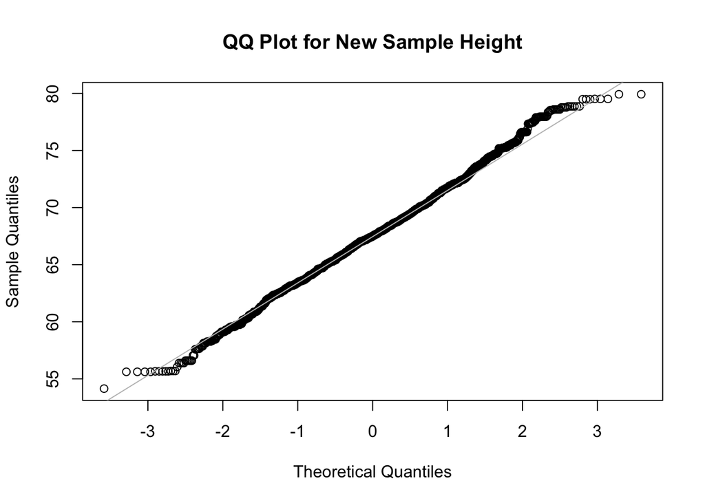

```r
qqnorm(nsh,main="QQ Plot for New Sample Height")
qqline(nsh,col="gray") #Create Q-Q plot for new sample height values.
```

The same as before, the height values are normally distributed.

### Weight

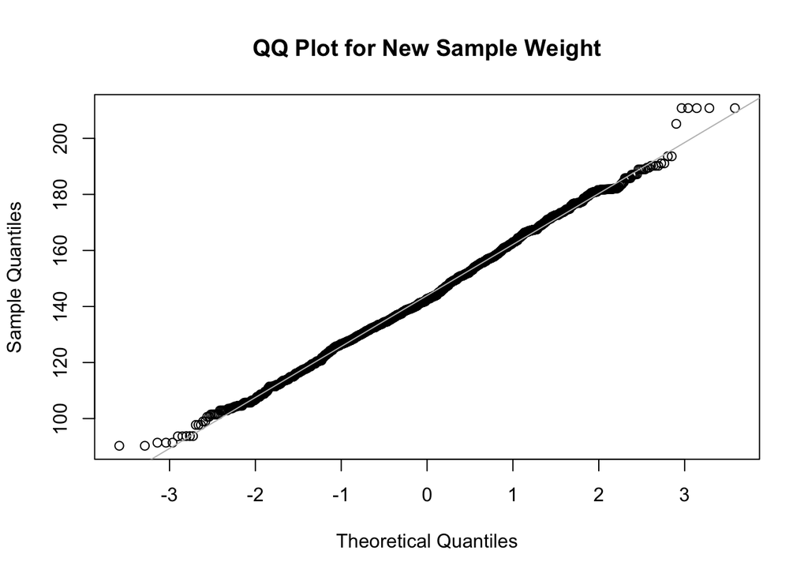

```r
qqnorm(nsw,main="QQ Plot for New Sample Weight")
qqline(nsw,col="gray") #Create Q-Q plot for new sample weight values.
```

The same as before, the weight values are normally distributed.

### Age

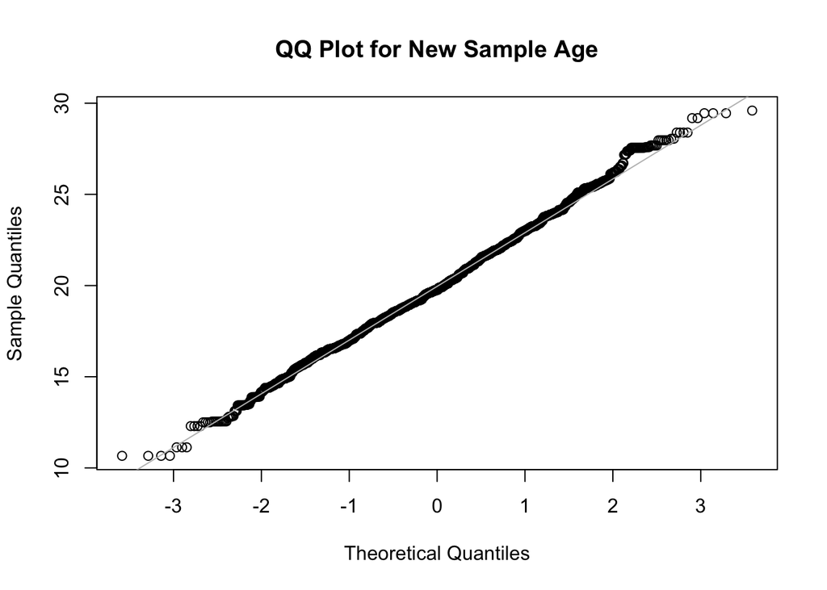

```r
qqnorm(nsa,main="QQ Plot for New Sample Age")
qqline(nsa,col="gray") #Create Q-Q plot for new sample age values.
```

The same as before, the age values are normally distributed.

### Number of Zombies Killed

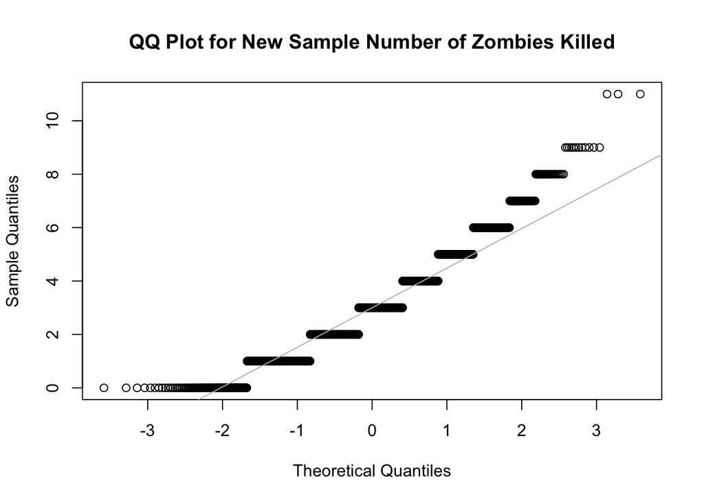

```r
qqnorm(nsz,main="QQ Plot for New Sample Number of Zombies Killed")
qqline(nsz,col="gray") #Create Q-Q plot for new sample number of zombies killed values.
```

The same as before, the number of zombies killed is not normally distributed with 99 random samples.

### Years of Education

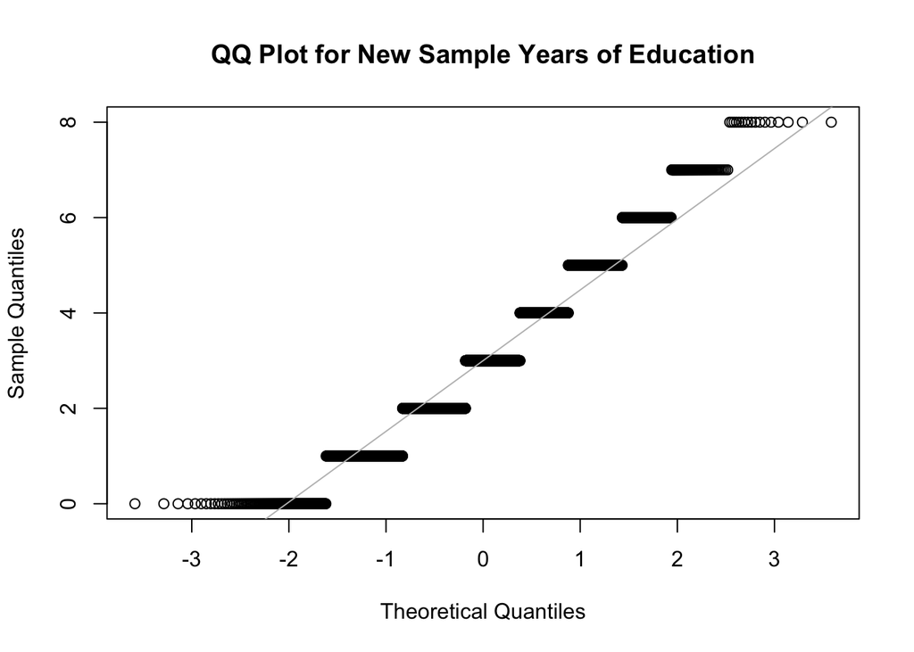

```r
qqnorm(nsy,main="QQ Plot for New Sample Years of Education")
qqline(nsy,col="gray") #Create Q-Q plot for new sample years of education values.
```

The same as before, the years of education is not normally distributed with 99 random samples.

## Challenges

1. Testing for what the distributions were for the number of zombies killed and the years of education.
2. Finding standard error for Question 5.
3. Creating confidence intervals for Question 5, both for the normal and Poisson distributions.
4. Creating 99 more random samples for Question 6. Did I do it right?
5. I’m kind of confused about what Question 6 is asking. Does he want me to find the means and standard deviations for the two vectors I’ve created, or just of the 99 more samples I found? I went with the 99 more samples found.